# CMSC320 Final Tutorial: COVID Death vs. Administration of Vaccination

Group Member: Chao-Wei Tu, Chiayo Lin

## 0: Introduction

The COVID-19 Pandemic is an on-going problem and a threat to our civilization that is yet to be solved. One of the most effective solutions in countries where contact-tracing and isolation result to no avail may be the robust administration of vaccines. Any delays on the administration of COVID vaccines may consequently lead to one too many innocent lives lost. This brings us to the topic of this tutorial, that is, to explore the relationship between COVID case fatality and the administration of vaccination. Divided up into five parts, this tutorial starts with collecting the data from publicly available sources, processing the data sets collected, exploring and analyze the processed data, testing a hypothesis, creating a machine learning model, and finally discussing the insights of our exploration regarding vaccination and COVID death.

```python
import numpy as np
import pandas as pd
import matplotlib.pyplot as plt
import matplotlib.dates as mdates
```

## 1: Collection

In this section we will collect COVID case and vaccination data from two different sources and store them into Pandas' data frames. The COVID case data set is provided by Johns Hopkins' CSSGI (https://git.io/JsLXg), whereas the vaccination data set comes from *Our World In Data* (https://git.io/Jt0wy). Both data sets are publicly available on Github and released under some non-proprietary licenses. Furthermore, since these data sets are accessible to the general public, our "experiment," or rather the exploration of the relationship between covid death and vaccination, can be easily replicated and verify by other parties.

### 1a. Collect COVID Cases Data

We will first obtain the COVID case dataset in CSV from the JHU's CSSGI on Github, then read it into a Pandas data frame. We are only interested in the covid confirm cases and death across states each day. The Github repository is being updated automatically every day using data from the US CDC, therefore, the code to be written later should reflect this.

```python
# get confirmed cases and death data
# source: <https://git.io/JsLXg>
csse_repo = (
  'https://raw.githubusercontent.com/'
  'CSSEGISandData/COVID-19/master/'
  'csse_covid_19_data/csse_covid_19_time_series/'
)

df_confirm = pd.read_csv(csse_repo + 'time_series_covid19_confirmed_US.csv')
df_death = pd.read_csv(csse_repo + 'time_series_covid19_deaths_US.csv')

# evaluate result
df_confirm.tail()
```

|  | UID | iso2 | iso3 | code3 | FIPS | Admin2 | Province_State | Country_Region | Lat | Long_ | ... | 5/7/21 | 5/8/21 | 5/9/21 | 5/10/21 | 5/11/21 | 5/12/21 | 5/13/21 | 5/14/21 | 5/15/21 | 5/16/21 |
| --- | --- | --- | --- | --- | --- | --- | --- | --- | --- | --- | --- | --- | --- | --- | --- | --- | --- | --- | --- | --- | --- |
| 3337 | 84056039 | US | USA | 840 | 56039.0 | Teton | Wyoming | US | 43.935225 | -110.589080 | ... | 3751 | 3751 | 3751 | 3755 | 3758 | 3760 | 3762 | 3765 | 3765 | 3765 |
| 3338 | 84056041 | US | USA | 840 | 56041.0 | Uinta | Wyoming | US | 41.287818 | -110.547578 | ... | 2217 | 2217 | 2217 | 2229 | 2232 | 2234 | 2237 | 2239 | 2239 | 2239 |
| 3339 | 84090056 | US | USA | 840 | 90056.0 | Unassigned | Wyoming | US | 0.000000 | 0.000000 | ... | 0 | 0 | 0 | 0 | 0 | 0 | 0 | 0 | 0 | 0 |
| 3340 | 84056043 | US | USA | 840 | 56043.0 | Washakie | Wyoming | US | 43.904516 | -107.680187 | ... | 911 | 911 | 911 | 912 | 913 | 914 | 918 | 918 | 918 | 918 |
| 3341 | 84056045 | US | USA | 840 | 56045.0 | Weston | Wyoming | US | 43.839612 | -104.567488 | ... | 651 | 651 | 651 | 651 | 651 | 651 | 651 | 651 | 651 | 651 |

5 rows × 492 columns

By observing the table schema above, we find that we need to transpose the table in such a way that it become rows of dates instead of columns of dates. Other columns other than the metrics in question for each date and state may be dropped.

### 2b. Collect Vaccination Data

The vaccination data set is provided by a different data source, however, this data set is still publicly available. Again, fetch from the Github repository and read it into a Pandas data frame. Like JHU's repository, this data set is also automatically curated and updated to reflect the latest statistics provided by the US CDC or the state government.

```python
# read vaccination data
# source: <https://git.io/Jt0wy>
df_vaccine = pd.read_csv((
  'https://raw.githubusercontent.com/'
  'owid/covid-19-data/master/'
  'public/data/vaccinations/us_state_vaccinations.csv'
))

# evaluate result
df_vaccine.tail()
```

|  | date | location | total_vaccinations | total_distributed | people_vaccinated | people_fully_vaccinated_per_hundred | total_vaccinations_per_hundred | people_fully_vaccinated | people_vaccinated_per_hundred | distributed_per_hundred | daily_vaccinations_raw | daily_vaccinations | daily_vaccinations_per_million | share_doses_used |
| --- | --- | --- | --- | --- | --- | --- | --- | --- | --- | --- | --- | --- | --- | --- |
| 8143 | 2021-05-12 | Wyoming | 374624.0 | 491255.0 | 202711.0 | 29.92 | 64.73 | 173179.0 | 35.03 | 84.88 | 1287.0 | 1639.0 | 2832.0 | 0.763 |
| 8144 | 2021-05-13 | Wyoming | 374754.0 | 491795.0 | 202831.0 | 29.95 | 64.75 | 173312.0 | 35.05 | 84.97 | 130.0 | 1623.0 | 2804.0 | 0.762 |
| 8145 | 2021-05-14 | Wyoming | 376441.0 | 492695.0 | 203422.0 | 30.14 | 65.04 | 174440.0 | 35.15 | 85.13 | 1687.0 | 1270.0 | 2194.0 | 0.764 |
| 8146 | 2021-05-15 | Wyoming | 378677.0 | 495435.0 | 204468.0 | 30.34 | 65.43 | 175581.0 | 35.33 | 85.60 | 2236.0 | 1272.0 | 2198.0 | 0.764 |
| 8147 | 2021-05-16 | Wyoming | 378799.0 | 495435.0 | 204569.0 | 30.36 | 65.45 | 175688.0 | 35.35 | 85.60 | 122.0 | 1261.0 | 2179.0 | 0.765 |

By observing the table schema above, this data set is in a format that is easier to deal with than the previous data set, because we only need drop a few columns that we don't need.

## 2: Processing

This step in the "Data Science" pipeline concerns the transformation of raw data frames directly from the CSVs collected in the previous step to something that is easier to work with. While the data sets are both available CSV formats, the data stored in each set are represented by different schemas. Therefore, these raw data frames will need to be cleaned up and reshaped before proceeding to further analysis.

### 2a. Process COVID Cases Data

Like what is mentioned above, the JHU's data set has the dates presented as columns. This is a problem because we would like it to be rows of dates in a time-series manner as that is easier to work with. In order to accomplish this, a helper function called `extract_metric` is written to extract the metrics (i.e. confirm or death) from the raw data frames by basically finding the sum of data from every county in each state, then transpose the portion of data frame so that the dates are presented as rows.

```python
# extract population by state/territory as a dictionary
population = df_death.groupby('Province_State')['Population'].sum()
```

```python
# helper:
#   extract metric from raw data frame as format
#
#     | date | state | value |
#
# params:
#   key_offset=[confirm:0|death:1]
#
def extract_metric(raw, key_offset=0):

  # get list of dates available from source
  dates = [*raw.keys()[(11 + key_offset):].tolist()]

  # compute sum of death by date for each state,
  df = raw.groupby(['Province_State'])[[*dates]].sum()

  # transpose it to get sum of death by state for each date
  df = df.transpose()

  # reset index so date (i.e. index) is a column
  df = df.reset_index()

  # melt death by states into data frame for each date
  df = df.melt(id_vars='index')

  # convert value to int
  df['value'] = df['value'].map(int)

  # consolidate column names
  df = df.rename(
    columns={
      'index'          : 'date',
      'Province_State' : 'state',
      'value'          : 'death' if key_offset else 'confirm'
    }
  )

  # transform dates from string to timestamps
  df['date'] = pd.to_datetime(df['date'], format='%m/%d/%y')

  return df
```

We will perform an inner merge on the metrics extracted from the confirm and death raw data frames for rows with the same date and state. The implication of an inner merge is that only rows with common date and state are merged, which is what we want because if either does not match (or is missing), then the entry wouldn't be useful anyway.

```python
# merge extracted metrices using common columns. inner merge is performed
# so rows with common date and state are remained in the merged data
df = pd.merge(
  extract_metric(df_confirm),
  extract_metric(df_death, 1),
  on=['date', 'state'],
  how='inner'
)

# evalute result
df.tail()
```

|  | date | state | confirm | death |
| --- | --- | --- | --- | --- |
| 27893 | 2021-05-12 | Wyoming | 58893 | 712 |
| 27894 | 2021-05-13 | Wyoming | 58996 | 712 |
| 27895 | 2021-05-14 | Wyoming | 59079 | 712 |
| 27896 | 2021-05-15 | Wyoming | 59079 | 712 |
| 27897 | 2021-05-16 | Wyoming | 59079 | 712 |

### 2b. Process Vaccination Data

Compared to JUH's date set, the vaccination data set is in an easier to work with format. So we just need to drop a few columns and perform a left merge so missing values are filled with NaN. Note that we have to use left merge because we know that the vaccination is not available until January 2021 and we need to keep the other data that are available prior to that date.

```python
# transform dates from strings to timestamps
df_vaccine['date'] = pd.to_datetime(df_vaccine['date'], format='%Y-%m-%d')

# consolidate column names
df_vaccine = df_vaccine.rename(
  columns={
    'location'                : 'state',
    'people_vaccinated'       : 'vaccinated',
    'people_fully_vaccinated' : 'fully_vaccinated',
  }
)

# consolidate columns
df_vaccine = df_vaccine[
  ['date', 'state', 'vaccinated', 'fully_vaccinated']
]

# rename entries w/ 'New York State' to 'New York'
df_vaccine.loc[df_vaccine['state'] == 'New York State', 'state'] = 'New York'

# merge grand df with vaccine df using common columns left merge is
# performed so missing values are filled with NaN
df = pd.merge(df, df_vaccine, on=['date', 'state'], how='left')

# evaluate result
df.tail()
```

|  | date | state | confirm | death | vaccinated | fully_vaccinated |
| --- | --- | --- | --- | --- | --- | --- |
| 27893 | 2021-05-12 | Wyoming | 58893 | 712 | 202711.0 | 173179.0 |
| 27894 | 2021-05-13 | Wyoming | 58996 | 712 | 202831.0 | 173312.0 |
| 27895 | 2021-05-14 | Wyoming | 59079 | 712 | 203422.0 | 174440.0 |
| 27896 | 2021-05-15 | Wyoming | 59079 | 712 | 204468.0 | 175581.0 |
| 27897 | 2021-05-16 | Wyoming | 59079 | 712 | 204569.0 | 175688.0 |

Note that there are other entries in the data frames that are not really states such as the US overseas territories and the cruise ships. These entries will be dropped since they don't provide much value to the objective of this tutorial and that due to the nature of these entities, much of their data are missing.

```python
# drop by indices for entries in merged data that are not "states"
df.drop(
  df[df["state"].isin([
    'Diamond Princess',         # cruise ship
    'Grand Princess',           # cruise ship
    'Northern Mariana Islands', # territory
    'Virgin Islands',           # territory
    'American Samoa',           # territory
    'Guam',                     # territory
    'Puerto Rico'               # territory
  ])].index,
  inplace=True
)

# now we should have 51 "states" (including District of Columbia)
len(set(df['state'])) == 51
```

```
True
```

The last expression above shall evaluate to true as there are 51 entities in the United States, that are 50 states and Washington DC.

## 3: Exploratory Analysis & Visualization

### 3a. Compute Relavent Statistcs

In this section, we will compute some statistics / metrices that may be useful in the following exploratory analysis of the data. In particular, we will compute daily new death, fetallity rate per 100K confirmed cases, and people fully/vaccinated per 100K population. Other metrics are also computed for the purpose of exploration and curiosity about how these data may look like.

```python
# prevalence (per # of people)
p = 100000

# populations for each row in df
pops = population[df['state']].tolist()

# compute daily new death
df['daily_death'] = df.loc[:, ["death"]].diff(axis = 0)
df.loc[df['date'] == "2020-01-22", ["daily_death"]] = 0

# compute case per 100k population
df['case_100k'] = (df['confirm'] / pops * p).round(1)

# compute fatality rate per 100k case
df['fatality_100k'] = (df['death'] / df['confirm'] * p).round(1)

# compute mortality rate per 100k population
df['mortality_100k'] = (df['death'] / pops * p).round(1)

# compute people vaccinated per 100k population
df['vaccinated_100k'] = (df['vaccinated'] / pops * p).round(1)

# compute people fully vaccinated per 100k population
df['fully_vaccinated_100k'] = (df['fully_vaccinated'] / pops * p).round(1)

# evaluate result
df.tail()
```

|  | date | state | confirm | death | vaccinated | fully_vaccinated | daily_death | case_100k | fatality_100k | mortality_100k | vaccinated_100k | fully_vaccinated_100k |
| --- | --- | --- | --- | --- | --- | --- | --- | --- | --- | --- | --- | --- |
| 27893 | 2021-05-12 | Wyoming | 58893 | 712 | 202711.0 | 173179.0 | 0.0 | 10175.7 | 1209.0 | 123.0 | 35025.1 | 29922.5 |
| 27894 | 2021-05-13 | Wyoming | 58996 | 712 | 202831.0 | 173312.0 | 0.0 | 10193.5 | 1206.9 | 123.0 | 35045.8 | 29945.5 |
| 27895 | 2021-05-14 | Wyoming | 59079 | 712 | 203422.0 | 174440.0 | 0.0 | 10207.9 | 1205.2 | 123.0 | 35148.0 | 30140.4 |
| 27896 | 2021-05-15 | Wyoming | 59079 | 712 | 204468.0 | 175581.0 | 0.0 | 10207.9 | 1205.2 | 123.0 | 35328.7 | 30337.5 |
| 27897 | 2021-05-16 | Wyoming | 59079 | 712 | 204569.0 | 175688.0 | 0.0 | 10207.9 | 1205.2 | 123.0 | 35346.1 | 30356.0 |

### 3b. Analysis and Visualization

```python
# helper: set x-axis formatter

def set_x_date_format(ax, fmt='%m/%y'):
  format = mdates.DateFormatter(fmt)
  ax.xaxis.set_major_formatter(format)
```

Let's start by looking at a few metrics across states, that among them include, cases per 100K population, daily new death, fatality per 100K confirmed cases, and vaccinated population per 100K population. By looking at the numbers in the context of 100K sample quantity, we are able to keep the number relative small yet sensitive, that is also much easier to comprehend.

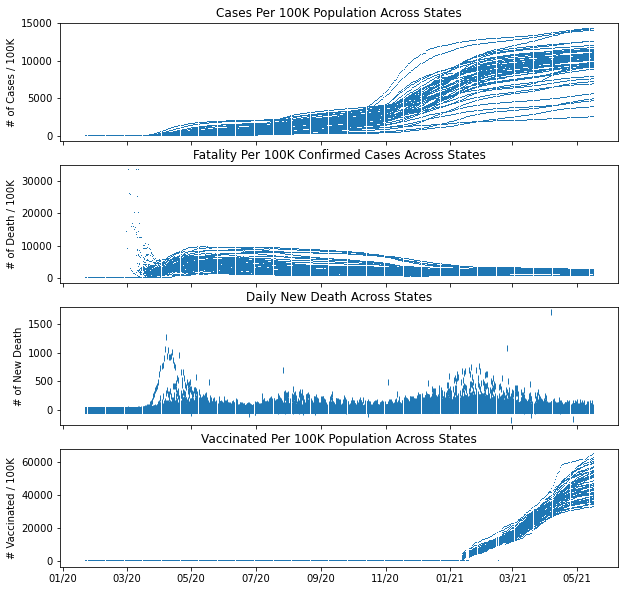

```python
fig, axs = plt.subplots(4)
fig.set_size_inches(10, 10)

for ax in axs.flat[:-1]:
  plt.setp(ax.get_xticklabels(), visible=False)

# set title for each subplot
axs[0].title.set_text('Cases Per 100K Population Across States')
axs[1].title.set_text('Fatality Per 100K Confirmed Cases Across States')
axs[2].title.set_text('Daily New Death Across States')
axs[3].title.set_text('Vaccinated Per 100K Population Across States')

# set y-axes labels
axs[0].set_ylabel('# of Cases / 100K')
axs[1].set_ylabel('# of Death / 100K')
axs[2].set_ylabel('# of New Death')
axs[3].set_ylabel('# Vaccinated / 100K')

# plot it
axs[0].plot_date(df['date'], df['case_100k'], ',')
axs[1].plot_date(df['date'], df['fatality_100k'], ',')
axs[2].plot_date(df['date'], df['daily_death'], '|')
axs[3].plot_date(df['date'], df['vaccinated_100k'].fillna(0), ',')

# set x-axis date format
set_x_date_format(axs[-1])

plt.show()
```

Now let's look at the mean case fatality per 100k people across states. Note that case fatality is the number of death in respect to the people who died from COVID. The reason that the average fatality is taken instead of having a plot for each state in the same figure because the objective here is to look at the over trend, and by having all 51 states in a single figure, the graph will be too chaotic to interpret.

```python
# get unique dates
dates = [*sorted(set(df['date']))]
```

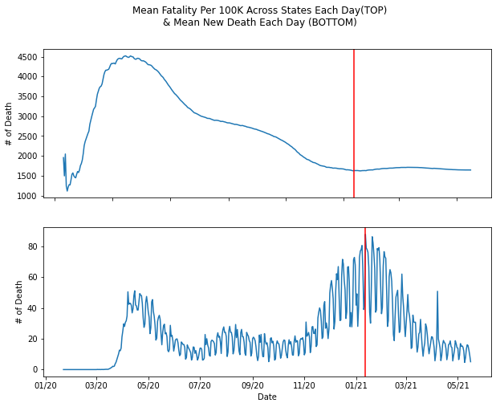

```python
# compute mean fatality (per 100k) each day
mean_fatality = []
for date in dates:
  mean_fatality.append(df[df['date'] == date]['fatality_100k'].mean())

# compute mean daily death each day
mean_daily_death = []
for date in dates:
  mean_daily_death.append(df[df['date'] == date]['daily_death'].mean())

fig, axs = plt.subplots(2)

# configure figure
fig.set_size_inches(10, 7.5)
fig.suptitle((
  'Mean Fatality Per 100K Across States Each Day(TOP)\n'
  '& Mean New Death Each Day (BOTTOM)'
))

# set labels
for ax in axs.flat:
    ax.set(xlabel='Date', ylabel='# of Death')
    ax.label_outer() # hide top plot label

# plot mean per 100K fatality
axs[0].plot_date(dates, mean_fatality, '-')

# plot daily new death
axs[1].plot_date(dates, mean_daily_death, '-')

# set x-axis formatter
set_x_date_format(axs[1])

# plot vaccine rollout day
rollout_date = df[df['vaccinated'].notna()].min()['date']
for ax in axs.flat:
  ax.axvline(x=rollout_date, color='r')

fig.show()
```

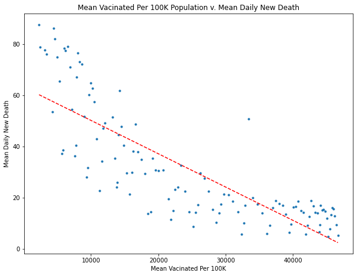

```python
# compute mean per 100K vaccinated
mean_vaccinated = []
for date in dates:
  mean_vaccinated.append(
    df[df['date'] == date]['vaccinated_100k'].mean()
  )

# configure plot
fig, ax = plt.subplots()
fig.set_size_inches(10, 7.5)
plt.title('Mean Vacinated Per 100K Population v. Mean Daily New Death')
plt.xlabel('Mean Vacinated Per 100K')
plt.ylabel('Mean Daily New Death')

# plot mean vaccinated vs mean daily death
plt.plot(mean_vaccinated, mean_daily_death, '.')
notnan_indices = np.isfinite(mean_vaccinated) & np.isfinite(mean_daily_death)

# hack: get rid of pairs with nan from python lists
x, y = [*zip(*filter(
  lambda p: not np.isnan(p[0]) and not np.isnan(p[1]),
  zip(mean_vaccinated, mean_daily_death)
))]

# compute and plot line of best fit
m, b = np.polyfit(x, y, 1)
model = np.poly1d((m, b))
plt.plot(x, model(x), 'r--')

plt.show()
```

As expected, the graph above shows a downward trend in the sense that as more and more people are getting vaccinated, the lesser there are for the new daily death. The line of best fit also shown a downward trend that allign well with the data points. It is important to note that it should be unclear of whether the vaccines are the fundamental cause of this decrease in the number of new death. bHowever, by only looking at the numbers provided here without other contexts, there seems to be a negative relationship between these two metrics. We will test this relationship further in the following section.

## 4: Hypothesis Testing & Machine Learning

In these days there are still a portion of vaccines disbelievers spreading misinformations about how the companies and governments are delivering ineffective vaccines to make money. However, in order to let vaccines do its job, vaccination coverage is crucial in stopping the spread of covid and more importantly stopping covid from evolving into more deadly virus. We need to bring up the numbers of vaccinated people to build up herd immunity in communities, so we want to use some sophisticated analysis to show the impact of vaccines to covid cases and deaths for the anti-vaxxers.

We first use linear regression, a machine learning technique, to fit a line for the number of people fully vaccinated versus the number of daily deaths for each states. Here we are using the interaction term to build the linear model. We use interaction terms when we think there are two or more factors that is effecting the output parameter. Here we think that on top of the number of people get fully vaccinated, which states you are living in also change the number of daily deaths due to the political demography of the states, as there seems to be a group of people in certain political party trying to promote that covid and vaccines are a hoax made by their opponent party.

```python
from sklearn.linear_model import LinearRegression
from scipy.stats import t
import math
```

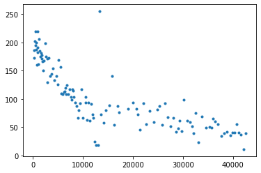

```python
md = df.loc[df['state'] == "New York"]
plt.plot(md["fully_vaccinated_100k"], md["daily_death"], '.')
plt.show()
```

The get_dummies help us transform our categorical variables into indicator variables. In other words, our categorical variable, states, will be converted into traits for each row of data. So for a data for Maryland, our column of Maryland would show 1, and 0 for other columns.

```python
df1 = df.drop(columns = [
  "date", "confirm", "death", "vaccinated", "fully_vaccinated",
  "case_100k", "fatality_100k", "mortality_100k", "vaccinated_100k"
])

df1_dum = pd.get_dummies(
  df1, columns = ['state'],
  prefix = 'in', drop_first = True
)

for state in filter(lambda s: 'in_' in s, df1_dum.columns):
  df1_dum['full_vax_100k*' + state] = \
    df1_dum['fully_vaccinated_100k'] * df1_dum[state]


df1_dum = df1_dum.dropna()

ind = df1_dum.drop(["daily_death"], axis = 1)
dep = df1_dum['daily_death']

# ind
lm = LinearRegression()
lm.fit(ind, dep)

lm.coef_
```

```
array([-4.44652534e-03, -9.43147800e+01,  2.56197753e+01, -6.90640027e+01,
        3.61437748e+02, -8.29338339e+01, -7.31633380e+01, -9.02371812e+01,
       -9.24652519e+01,  6.09349530e+01,  2.71624820e+01, -9.32859632e+01,
       -8.91443166e+01, -3.33787567e+01, -4.80272903e+01, -6.90237437e+01,
       -6.75665825e+01, -5.16259804e+01, -6.01449929e+01, -9.16270099e+01,
       -6.62704069e+01, -3.62741165e+01, -6.15104445e+01, -8.05774888e+01,
       -6.34043298e+01, -5.03492134e+01, -8.91113522e+01, -8.94804592e+01,
       -6.69691822e+01, -9.02573487e+01, -2.34813943e+01, -7.60999101e+01,
        5.76143905e+01, -1.90877793e+01, -9.36819304e+01, -3.47418278e+01,
       -5.61936040e+01, -8.41721813e+01,  1.54825753e+01, -8.79690548e+01,
       -4.16921894e+01, -9.02867092e+01, -2.21599196e+01,  1.88027176e+02,
       -8.49255764e+01, -9.49648350e+01, -2.28116152e+01, -6.98017023e+01,
       -7.78273369e+01, -7.01577188e+01, -9.14009973e+01,  4.41445664e-03,
       -7.88140126e-05,  3.35238717e-03, -9.84185759e-03,  4.23209451e-03,
        3.92664249e-03,  4.32032787e-03,  4.35524490e-03,  5.31154789e-04,
       -2.71929409e-05,  4.37500835e-03,  4.24379234e-03,  3.00768366e-03,
        2.77238801e-03,  3.68989901e-03,  3.47762589e-03,  3.48086977e-03,
        3.22061517e-03,  4.35417417e-03,  3.86389043e-03,  3.00832552e-03,
        5.06826669e-03,  4.25726422e-03,  3.06418295e-03,  2.76430321e-03,
        4.29044835e-03,  4.29319464e-03,  3.46758582e-03,  4.30074577e-03,
        3.08565365e-03,  3.94912531e-03,  1.19787089e-03,  2.00457939e-03,
        4.38750734e-03,  2.44241947e-03,  4.01159036e-03,  4.15803103e-03,
        1.55959802e-03,  4.25002699e-03,  2.57768906e-03,  4.30041959e-03,
        1.29952405e-03, -5.22371470e-03,  4.06998615e-03,  4.43218824e-03,
        2.65703756e-03,  3.77176122e-03,  3.86780958e-03,  3.85575590e-03,
        4.25925510e-03])
```

Sklearn has this nice linear regression library that allows users to put in multiple independent variables and do interaction terms. The terms generated above can be interpreted as follows. $$y = c_0*#_fully_vaccinated_100k + c_1*in_Alaska + ... + c_50*fully_vaccinated_100k*in_Alaska + ... + intercept$$ where c are the coefficients generated from above. This is a linear model in high dimension. However, from the linear function above, we can get a linear relationship for each states by getting the right coefficients. Since we now put our states into indicator variable, we can simply pick the coefficient that the variable is related to the state we are interested in. Take Maryland as an example. All variables except _in*maryland* and _full_vax_100k*in*maryland* evaluate to 0. By combining the coeficients for _fully_vaccinated*100k*, *intercept*, _in*maryland*, and _full_vax_100k*in*maryland*, we can get the model for Maryland in the form $y = \alpha + \beta * x$. We can use this way to find a line for every states.

```python
state_lr = {}

for state in set(df1["state"]):
  if state == "Alabama":
    state_lr[state] = [lm.coef_[0], lm.intercept_]
  else:
    index = list(ind.columns).index("full_vax_100k*in_" + state)
    index2 = list(ind.columns).index("in_"+state)
    state_lr[state] = [lm.coef_[0] + lm.coef_[index], lm.intercept_ + lm.coef_[index2]]

state_lr_df = pd.DataFrame.from_dict(state_lr, orient = 'index', columns = ["slope", "intercept"])
state_lr_df
```

|  | slope | intercept |
| --- | --- | --- |
| North Carolina | -0.002442 | 76.890242 |
| Alaska | -0.000032 | 1.663241 |
| Kansas | -0.000969 | 28.411438 |
| Nevada | -0.000979 | 29.008839 |
| North Dakota | -0.000059 | 2.296091 |
| Texas | -0.009670 | 284.005197 |
| Ohio | -0.002004 | 61.236193 |
| Florida | -0.003915 | 156.912974 |
| New Mexico | -0.000497 | 19.878111 |
| Mississippi | -0.001382 | 32.573691 |
| Wyoming | -0.000187 | 4.577024 |
| Minnesota | -0.000189 | 15.400532 |
| Hawaii | -0.000072 | 2.692058 |
| Nebraska | -0.000153 | 6.497562 |
| Utah | -0.000377 | 11.052445 |
| Montana | -0.000156 | 6.866669 |
| Vermont | -0.000014 | 1.013186 |
| Louisiana | -0.001226 | 35.833028 |
| Arizona | -0.004525 | 121.597796 |
| Oklahoma | -0.000435 | 39.784417 |
| California | -0.014288 | 457.415769 |
| Connecticut | -0.000520 | 22.814683 |
| Delaware | -0.000126 | 5.740840 |
| Maine | -0.000092 | 4.351011 |
| Rhode Island | -0.000196 | 8.008966 |
| District of Columbia | -0.000091 | 3.512769 |
| Maryland | -0.000583 | 29.707614 |
| Michigan | 0.000622 | 34.467576 |
| Idaho | -0.000203 | 6.833704 |
| Indiana | -0.001674 | 47.950731 |
| New York | -0.003249 | 153.592411 |
| Virginia | -0.001789 | 73.166406 |
| Oregon | -0.000288 | 11.805840 |
| Iowa | -0.000757 | 26.954277 |
| Colorado | -0.000214 | 13.044187 |
| Pennsylvania | -0.002887 | 111.460596 |
| Wisconsin | -0.000591 | 25.820302 |
| Georgia | -0.004474 | 123.140503 |
| Massachusetts | -0.001438 | 59.703904 |
| Missouri | -0.001682 | 45.628808 |
| South Carolina | -0.001869 | 54.285832 |
| Alabama | -0.004447 | 95.978021 |
| West Virginia | -0.000579 | 18.150684 |
| Kentucky | -0.000966 | 44.352041 |
| Tennessee | -0.003147 | 73.818101 |
| Arkansas | -0.001094 | 26.914018 |
| Washington | -0.000675 | 26.176319 |
| Illinois | -0.001439 | 62.599264 |
| New Hampshire | -0.000146 | 5.720672 |
| South Dakota | -0.000146 | 5.691312 |
| New Jersey | -0.001361 | 72.496627 |

Now we have the slope and intercept for the linear model of each state. Recall that our purpose is to find the relationship between the independent variable (fully vaccinated per 100k) and dependent variable (daily death), so we are only going to focus on the slope.

Let us set up hypothesis tests for the relation between the coverage of fully vaccinated people versus daily deaths in each states. We are going to do a model utility test. Our null hypothesis will be that there is no relationship between the two factor and the alternative hypothesis will be there are negative relationship. Also we set our significance level to 0.05. So $$H_0: \beta = 0$$ $$H_a: \beta < 0$$ $$significance\ level = 0.05$$ where $\beta$ represent the slope parameter of the linear model $y = \alpha + \beta x$. The slope represents the change in dependent variable per unit change of the independent variable. In this context, the slope is the change in the number of daily deaths per 1/100k of the population get fully vaccinated.

```python
for state in set(df1["state"]):
  state_df = df1.loc[df1["state"] == state]
  state_df = state_df.dropna()
  n = len(state_df)
  if n == 0 :
    print(state)

  # linear model for the given states
  y = lambda x: state_lr[state][0] * x + state_lr[state][1]

  # compute sum of squared error
  sse = 0
  for i, r in state_df.iterrows():
    y_hat = y(r["fully_vaccinated_100k"])
    sse += (r["daily_death"] - y_hat)**2

  # compute standard error to get the t score
  s_squared = sse/(n - 2)
  s_xx = sum(map(
    lambda x: x**2,
    state_df["fully_vaccinated_100k"])) \
      - sum(state_df["fully_vaccinated_100k"])**2 / n

  t_stat = state_lr[state][0] / math.sqrt(s_squared/s_xx)

  p_val = t.cdf(t_stat, n - 2)
  state_lr[state].append(p_val)

state_lr_df = pd.DataFrame.from_dict(state_lr, orient = 'index', columns = ["slope", "intercept", "p value"])

state_lr_df["reject"] = state_lr_df.apply(lambda row: True if row["p value"] < 0.05 else False, axis = 1)

state_lr_df
```

|  | slope | intercept | p value | reject |
| --- | --- | --- | --- | --- |
| North Carolina | -0.002442 | 76.890242 | 1.196039e-15 | True |
| Alaska | -0.000032 | 1.663241 | 1.174963e-01 | False |
| Kansas | -0.000969 | 28.411438 | 5.740827e-05 | True |
| Nevada | -0.000979 | 29.008839 | 2.417094e-15 | True |
| North Dakota | -0.000059 | 2.296091 | 2.642628e-03 | True |
| Texas | -0.009670 | 284.005197 | 2.178054e-24 | True |
| Ohio | -0.002004 | 61.236193 | 2.256330e-26 | True |
| Florida | -0.003915 | 156.912974 | 1.270418e-21 | True |
| New Mexico | -0.000497 | 19.878111 | 5.513311e-22 | True |
| Mississippi | -0.001382 | 32.573691 | 3.902230e-15 | True |
| Wyoming | -0.000187 | 4.577024 | 2.993486e-04 | True |
| Minnesota | -0.000189 | 15.400532 | 3.263713e-02 | True |
| Hawaii | -0.000072 | 2.692058 | 3.171162e-02 | True |
| Nebraska | -0.000153 | 6.497562 | 1.586743e-03 | True |
| Utah | -0.000377 | 11.052445 | 3.957544e-08 | True |
| Montana | -0.000156 | 6.866669 | 4.565927e-03 | True |
| Vermont | -0.000014 | 1.013186 | 7.851095e-03 | True |
| Louisiana | -0.001226 | 35.833028 | 4.429284e-14 | True |
| Arizona | -0.004525 | 121.597796 | 2.048351e-15 | True |
| Oklahoma | -0.000435 | 39.784417 | 3.754146e-01 | False |
| California | -0.014288 | 457.415769 | 6.602493e-25 | True |
| Connecticut | -0.000520 | 22.814683 | 2.321816e-07 | True |
| Delaware | -0.000126 | 5.740840 | 4.626428e-06 | True |
| Maine | -0.000092 | 4.351011 | 3.263961e-04 | True |
| Rhode Island | -0.000196 | 8.008966 | 5.942403e-13 | True |
| District of Columbia | -0.000091 | 3.512769 | 7.350377e-08 | True |
| Maryland | -0.000583 | 29.707614 | 1.250904e-13 | True |
| Michigan | 0.000622 | 34.467576 | 9.658019e-01 | False |
| Idaho | -0.000203 | 6.833704 | 6.058338e-06 | True |
| Indiana | -0.001674 | 47.950731 | 7.535709e-17 | True |
| New York | -0.003249 | 153.592411 | 1.065980e-26 | True |
| Virginia | -0.001789 | 73.166406 | 1.325784e-05 | True |
| Oregon | -0.000288 | 11.805840 | 1.250533e-04 | True |
| Iowa | -0.000757 | 26.954277 | 3.018464e-05 | True |
| Colorado | -0.000214 | 13.044187 | 4.144910e-04 | True |
| Pennsylvania | -0.002887 | 111.460596 | 3.180756e-09 | True |
| Wisconsin | -0.000591 | 25.820302 | 7.930822e-08 | True |
| Georgia | -0.004474 | 123.140503 | 8.727392e-15 | True |
| Massachusetts | -0.001438 | 59.703904 | 5.833415e-30 | True |
| Missouri | -0.001682 | 45.628808 | 1.526445e-04 | True |
| South Carolina | -0.001869 | 54.285832 | 4.099918e-10 | True |
| Alabama | -0.004447 | 95.978021 | 2.286828e-11 | True |
| West Virginia | -0.000579 | 18.150684 | 3.186365e-03 | True |
| Kentucky | -0.000966 | 44.352041 | 2.412842e-03 | True |
| Tennessee | -0.003147 | 73.818101 | 3.052148e-14 | True |
| Arkansas | -0.001094 | 26.914018 | 3.412825e-07 | True |
| Washington | -0.000675 | 26.176319 | 3.039208e-06 | True |
| Illinois | -0.001439 | 62.599264 | 4.468448e-10 | True |
| New Hampshire | -0.000146 | 5.720672 | 4.042378e-07 | True |
| South Dakota | -0.000146 | 5.691312 | 5.115011e-06 | True |
| New Jersey | -0.001361 | 72.496627 | 3.070524e-09 | True |

For almost all the states, we reject the null hypothesis which says the number of people fully vaccinated has no relationship to daily deaths. In other words, the vaccinces seems to reduce the number of daily cases in most of the states. Notice that we failed to reject null hypothesis for Alaska, Oklahoma, and Michigan states.

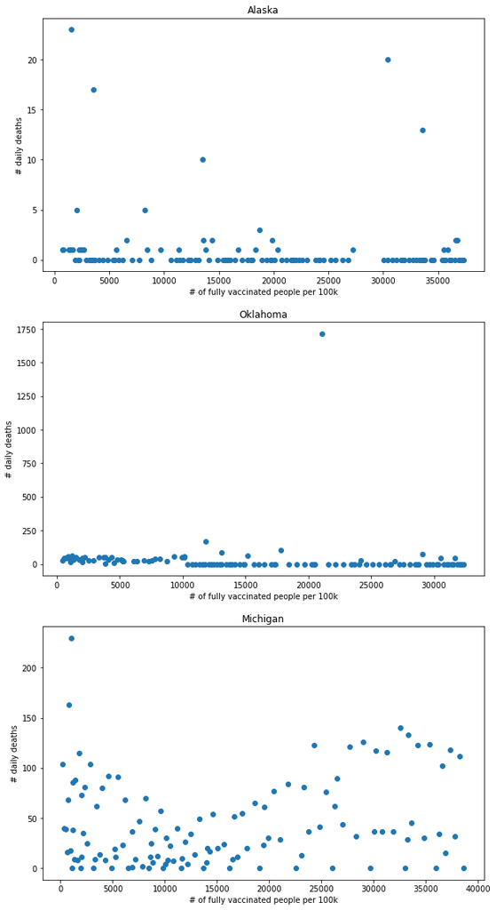

```python
fig, axs = plt.subplots(3)
fig.set_size_inches(10, 20)

for i, state in enumerate(["Alaska", "Oklahoma", "Michigan"]):
  s = df.loc[df['state'] == state]
  axs[i].scatter(s["fully_vaccinated_100k"], s["daily_death"])
  axs[i].set_title(state)
  axs[i].set_xlabel("# of fully vaccinated people per 100k")
  axs[i].set_ylabel("# daily deaths")
```

## 5: Insights

In this tutorial, we have imperatively carried out the steps neccesary to show the relationship between vaccination and COVID death through our "data science pipeline." Let's recap that the objective of this tutorial is to explore the relationship between vaccination and COVID death. To do that we first collect appropriate data sets, process it, then explore different metrics derived from the data. We then fit a linear regression model using the number of the propotion of (fully) vaccinated population in respect to the number of new death for each state using interaction terms. Additionally, our hypothesis testing suggests that, in general, there may be a negative relationship between the propotion of vaccinated population and death. Although we also found that for some states where COVID death weren't that prominant or due to the "second coming of COVID" as the vaccines were still rolling out such the case of Michigan), we fail to reject the null hypothesis. While this tutorial is not an attempt nor will be sufficent to prove the effectiveness of the vaccines, however, it is imperative for us to vaccinate the population.